# Sample Results Report

Erica Wozniak

16 June 2016

## Introduction

This document serves as an example of how I typically present my results in a reproducible, self-contained report using the `knitr` package in R, as well as my own table-making and plotting packages on [GitHub](https://github.com/emwozniak). I prefer to output results as HTML web documents since HTML allows for flexible formatting with custom CSS styles, inclusion of links to document sections, and the ability to incorporate `shiny` widgets (such as the app related to this document found [here](https://emwozniak.shinyapps.io/shiny/)) into the output.

## Summary statistics

### Table 1: Clinical characteristics by treatment status

Since this was a randomized controlled trial, we expect no significant differences in demographic or clinical characteristics by treatment status. Significant statistical tests (p < 0.05) indicate an imbalance in characteristics that should be evaluated with care in later analyses.

|  | D-penicillamine (N = 158) | Placebo (N = 154) | Overall (N = 312) | p-value |
| --- | --- | --- | --- | --- |
| **Age (years)** |  |  |  | 0.018 |
| Count | 158 | 154 | 312 | t-test |
| Mean (SD) | 51.42 (11.01) | 48.58 ( 9.96) | 50.02 (10.58) |  |
| Median (IQR) | 51.93 (15.92) | 48.11 (14.37) | 49.79 (14.48) |  |
| Q1, Q3 | 42.98, 58.90 | 41.43, 55.80 | 42.24, 56.71 |  |
| Min, Max | 26.28, 78.44 | 30.57, 74.52 | 26.28, 78.44 |  |
| Missing | 0 | 0 | 0 |  |
| **Sex** |  |  |  | 0.421 |
| Count (%) | 158 (50.64%) | 154 (49.36%) | 312 | Chi-square |
| (Row %)(Col %) |  |  |  |  |
| **Male** | 21 (58.33%) (13.29%) | 15 (41.67%) ( 9.74%) | 36 (100.00%) (11.54%) |  |
| **Female** | 137 (49.64%) (86.71%) | 139 (50.36%) (90.26%) | 276 (100.00%) (88.46%) |  |
| Missing | 0 | 0 | 0 |  |
| **Enlarged liver** |  |  |  | 0.088 |
| Count (%) | 158 (50.64%) | 154 (49.36%) | 312 | Chi-square |
| (Row %)(Col %) |  |  |  |  |
| **No** | 85 (55.92%) (53.80%) | 67 (44.08%) (43.51%) | 152 (100.00%) (48.72%) |  |
| **Yes** | 73 (45.62%) (46.20%) | 87 (54.37%) (56.49%) | 160 (100.00%) (51.28%) |  |
| Missing | 0 | 0 | 0 |  |
| **Edema** |  |  |  | 0.877 |
| Count (%) | 158 (50.64%) | 154 (49.36%) | 312 | Chi-square |
| (Row %)(Col %) |  |  |  |  |
| **No edema** | 132 (50.19%) (83.54%) | 131 (49.81%) (85.06%) | 263 (100.00%) (84.29%) |  |
| **Treated edema** | 16 (55.17%) (10.13%) | 13 (44.83%) ( 8.44%) | 29 (100.00%) ( 9.29%) |  |
| **Edema despite treatment** | 10 (50.00%) ( 6.33%) | 10 (50.00%) ( 6.49%) | 20 (100.00%) ( 6.41%) |  |
| Missing | 0 | 0 | 0 |  |
| **Cholesterol (mg/dl)** |  |  |  | 0.545 |
| Count | 140 | 144 | 284 | Wilcoxon rank-sum |
| Mean (SD) | 365.01 (209.54) | 373.88 (252.48) | 369.51 (231.94) |  |
| Median (IQR) | 315.50 (169.25) | 303.50 (122.75) | 309.50 (150.50) |  |
| Q1, Q3 | 247.75, 417.00 | 254.25, 377.00 | 249.50, 400.00 |  |
| Min, Max | 127.00, 1712.00 | 120.00, 1775.00 | 120.00, 1775.00 |  |
| Missing | 18 | 10 | 28 |  |
| **Platelet count** |  |  |  | 0.554 |
| Count | 156 | 152 | 308 | t-test |
| Mean (SD) | 258.75 (100.32) | 265.20 ( 90.73) | 261.94 (95.61) |  |
| Median (IQR) | 255.00 (132.50) | 259.50 (115.75) | 257.00 (122.75) |  |
| Q1, Q3 | 189.50, 322.00 | 206.75, 322.50 | 199.75, 322.50 |  |
| Min, Max | 62.00, 563.00 | 71.00, 487.00 | 62.00, 563.00 |  |
| Missing | 2 | 2 | 4 |  |
| **Disease stage** |  |  |  | 0.205 |
| Count (%) | 158 (50.64%) | 154 (49.36%) | 312 | Fisher exact |
| (Row %)(Col %) |  |  |  |  |
| **I** | 12 (75.00%) ( 7.59%) | 4 (25.00%) ( 2.60%) | 16 (100.00%) ( 5.13%) |  |
| **II** | 35 (52.24%) (22.15%) | 32 (47.76%) (20.78%) | 67 (100.00%) (21.47%) |  |
| **III** | 56 (46.67%) (35.44%) | 64 (53.33%) (41.56%) | 120 (100.00%) (38.46%) |  |
| **IV** | 55 (50.46%) (34.81%) | 54 (49.54%) (35.06%) | 109 (100.00%) (34.94%) |  |
| Missing | 0 | 0 | 0 |  |

Patients with unknown treatment status are excluded.

## Survival analyses

### Sample web application

Please [click here](https://emwozniak.shinyapps.io/shiny/) to view a sample interactive web app.

### Survival by treatment

A Kaplan-Meier survival plot is given below for time to death by treatment status, with patients who received a transplant censored at the time of surgery.

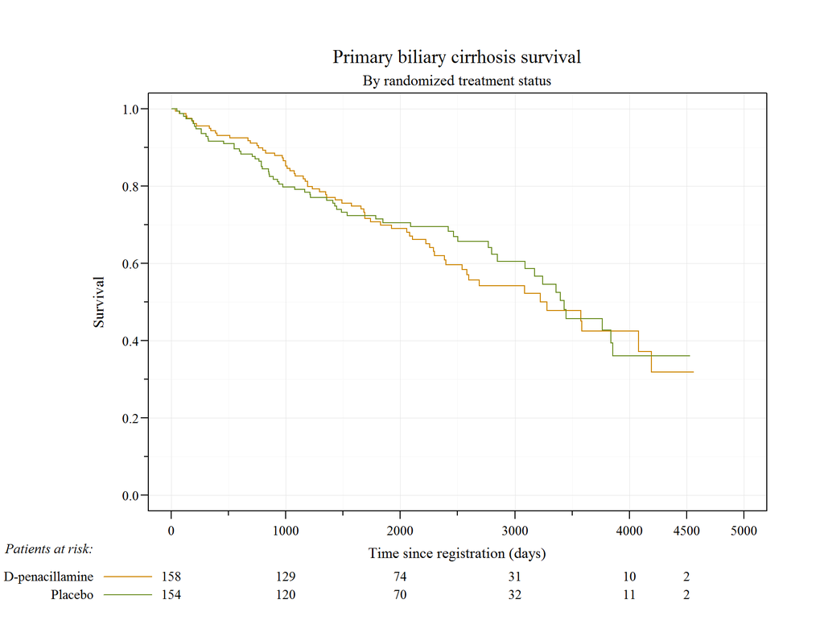

## Conclusions

Imbalances in age by treatment status after randomization should be addressed. Kaplan-Meier estimates do not show significant differences in survival outcomes between patients receiving the experimental treatment and placebo.